# LBB R Data Visualization - Benarivo

Benarivo

19/04/2020

```r
library(dplyr)
library(tidyr)
library(lubridate)
library(ggplot2)
```

In this project, we will visualize netflix data and find insights from the data.

# 1 Import Data

First we need to import the data using ‘read.csv’.

```r
netflix <- read.csv("netflix_titles.csv",na.strings=c("","NA"))
```

# 2 Inspect Data

After importing the data, we need to explore the dataset.

Now let’s print the first 10 rows from the dataset.

```r
head(netflix, 10)
```

```
##     show_id    type                                   title
## 1  81145628   Movie Norm of the North: King Sized Adventure
## 2  80117401   Movie              Jandino: Whatever it Takes
## 3  70234439 TV Show                      Transformers Prime
## 4  80058654 TV Show        Transformers: Robots in Disguise
## 5  80125979   Movie                            #realityhigh
## 6  80163890 TV Show                                 Apaches
## 7  70304989   Movie                                Automata
## 8  80164077   Movie      Fabrizio Copano: Solo pienso en mi
## 9  80117902 TV Show                            Fire Chasers
## 10 70304990   Movie                             Good People
##                           director
## 1         Richard Finn, Tim Maltby
## 2                             <NA>
## 3                             <NA>
```

[output cut: 62 more lines]

Additionally, let’s print 10 last rows from our dataset.

```r
tail(netflix, 10)
```

```
##       show_id    type                                       title director
## 6225 70304979 TV Show             Anthony Bourdain: Parts Unknown     <NA>
## 6226 70153412 TV Show                                     Frasier     <NA>
## 6227 70243132 TV Show                         La Familia P. Luche     <NA>
## 6228 80005756 TV Show                The Adventures of Figaro Pho     <NA>
## 6229 80159925 TV Show                                    Kikoriki     <NA>
## 6230 80000063 TV Show                                Red vs. Blue     <NA>
## 6231 70286564 TV Show                                       Maron     <NA>
## 6232 80116008   Movie      Little Baby Bum: Nursery Rhyme Friends     <NA>
## 6233 70281022 TV Show A Young Doctor's Notebook and Other Stories     <NA>
## 6234 70153404 TV Show                                     Friends     <NA>
##                                                                                                                                                      cast
## 6225                                                                                                                                     Anthony Bourdain
## 6226                                                                Kelsey Grammer, Jane Leeves, David Hyde Pierce, Peri Gilpin, John Mahoney, Dan Butler
## 6227                    Eugenio Derbez, Consuelo Duval, Luis Manuel Ã\201vila, Regina BlandÃ³n, Miguel Perez, Barbara Torres, Dalilah Polanco, Pierre Angelo
```

[output cut: 40 more lines]

From above, we can see that the data has these variables:

1. show_id: Unique ID for every Movie / TV Show
2. type: Identifier - A Movie or TV Show
3. title: Title of the Movie / Tv Show
4. director: Director of the Movie
5. cast: Actors involved in the movie / show
6. country: Country where the movie / show was produced
7. date_added: Date it was added on Netflix
8. release_year: Actual Release year of the move / show
9. rating: TV Rating of the movie / show
10. duration: Total Duration - in minutes or number of seasons
11. listed_in: Genre
12. description: The summary description

# 3 Data Cleaning

In this analyisis, unique ID for every movie or tv show is not needed. Thus ‘show_id’ shall be removed.

```r
netflix <- netflix %>%
  select(-show_id)
```

Additionally, we can print the information of the data type of each variable using ‘str()’:

```r
str(netflix)
```

```
## 'data.frame':    6234 obs. of  11 variables:
##  $ type        : Factor w/ 2 levels "Movie","TV Show": 1 1 2 2 1 2 1 1 2 1 ...
##  $ title       : Factor w/ 6172 levels "'89","#realityhigh",..: 3598 2463 5710 5714 2 418 478 1651 1714 1960 ...
##  $ director    : Factor w/ 3301 levels "Ã–mer Faruk Sorak",..: 2548 NA NA NA 946 NA 986 2626 NA 1143 ...
##  $ cast        : Factor w/ 5469 levels "4Minute, B1A4, BtoB, ELSIE, EXID, EXO, Got7, INFINITE, KARA, Shinee, Sistar, VIXX, Nine Muses, BTS, Secret, Topp Dogg",..: 205 2172 3999 5323 3759 211 491 1589 NA 2139 ...
##  $ country     : Factor w/ 554 levels "Argentina","Argentina, Brazil, France, Poland, Germany, Denmark",..: 499 380 444 444 444 335 49 77 444 539 ...
##  $ date_added  : Factor w/ 1524 levels " April 1, 2014",..: 1524 1523 1522 1522 1521 1521 1521 1521 1521 1521 ...
##  $ release_year: int  2019 2016 2013 2016 2017 2016 2014 2017 2017 2014 ...
##  $ rating      : Factor w/ 14 levels "G","NC-17","NR",..: 10 9 13 12 7 9 6 9 9 6 ...
##  $ duration    : Factor w/ 201 levels "1 Season","10 min",..: 192 196 1 1 201 1 16 159 1 192 ...
##  $ listed_in   : Factor w/ 461 levels "Action & Adventure",..: 111 421 382 382 168 218 338 421 273 58 ...
##  $ description : Factor w/ 6226 levels "\"Brooklyn Nine-Nine\" star Chelsea Peretti showcases her diverse talents in this dark yet silly reimagining of"| __truncated__,..: 1903 3522 6130 5586 5869 972 3060 2448 1744 779 ...
```

From above, we can see several changes should be implemented: 1. ‘title’ to be changed as character 2. ‘director’ to be changed as character 3. ‘cast’ to be changed as character 4. ‘date_added’ to be changed as date 5. ‘release_year’ to be changed as factor 6. ‘description’ to be changed as character

```r
netflix$title <- as.character(netflix$title)
netflix$director <- as.character(netflix$director)
netflix$cast <- as.character(netflix$cast)
netflix$date_added <- mdy(netflix$date_added)
netflix$release_year <- as.factor(netflix$release_year)
netflix$description <- as.character(netflix$description)
```

Let’s check the changes we have made:

```r
head(netflix,10)
```

```
##       type                                   title
## 1    Movie Norm of the North: King Sized Adventure
## 2    Movie              Jandino: Whatever it Takes
## 3  TV Show                      Transformers Prime
## 4  TV Show        Transformers: Robots in Disguise
## 5    Movie                            #realityhigh
## 6  TV Show                                 Apaches
## 7    Movie                                Automata
## 8    Movie      Fabrizio Copano: Solo pienso en mi
## 9  TV Show                            Fire Chasers
## 10   Movie                             Good People
##                           director
## 1         Richard Finn, Tim Maltby
## 2                             <NA>
## 3                             <NA>
```

[output cut: 62 more lines]

```r
str(netflix)
```

```
## 'data.frame':    6234 obs. of  11 variables:
##  $ type        : Factor w/ 2 levels "Movie","TV Show": 1 1 2 2 1 2 1 1 2 1 ...
##  $ title       : chr  "Norm of the North: King Sized Adventure" "Jandino: Whatever it Takes" "Transformers Prime" "Transformers: Robots in Disguise" ...
##  $ director    : chr  "Richard Finn, Tim Maltby" NA NA NA ...
##  $ cast        : chr  "Alan Marriott, Andrew Toth, Brian Dobson, Cole Howard, Jennifer Cameron, Jonathan Holmes, Lee Tockar, Lisa Duru"| __truncated__ "Jandino Asporaat" "Peter Cullen, Sumalee Montano, Frank Welker, Jeffrey Combs, Kevin Michael Richardson, Tania Gunadi, Josh Keaton"| __truncated_…
##  $ country     : Factor w/ 554 levels "Argentina","Argentina, Brazil, France, Poland, Germany, Denmark",..: 499 380 444 444 444 335 49 77 444 539 ...
##  $ date_added  : Date, format: "2019-09-09" "2016-09-09" ...
##  $ release_year: Factor w/ 72 levels "1925","1942",..: 71 68 65 68 69 68 66 69 69 66 ...
##  $ rating      : Factor w/ 14 levels "G","NC-17","NR",..: 10 9 13 12 7 9 6 9 9 6 ...
##  $ duration    : Factor w/ 201 levels "1 Season","10 min",..: 192 196 1 1 201 1 16 159 1 192 ...
##  $ listed_in   : Factor w/ 461 levels "Action & Adventure",..: 111 421 382 382 168 218 338 421 273 58 ...
##  $ description : chr  "Before planning an awesome wedding for his grandfather, a polar bear king must take back a stolen artifact from"| __truncated__ "Jandino Asporaat riffs on the challenges of raising kids and serenades the audience with a rousing rendition of"| __truncated__ "With the help of…
```

The changes have been implemented to our data.

Now, we need to check the missing data data.

```r
colSums(is.na(netflix))
```

```
##         type        title     director         cast      country   date_added
##            0            0         1969          570          476           11
## release_year       rating     duration    listed_in  description
##            0           10            0            0            0
```

In this case to analyse the data, it is okay to have missing data in the ‘director’ and ‘cast’. However, we need the data of the ‘country’, ‘date_added’ and ‘rating’. Therefore we will remove the data with missing information of ‘country’, ‘date_added’ and ‘rating’.

```r
netflix <- netflix %>%  drop_na(country, date_added, rating)
```

```r
colSums(is.na(netflix))
```

```
##         type        title     director         cast      country   date_added
##            0            0         1653          487            0            0
## release_year       rating     duration    listed_in  description
##            0            0            0            0            0
```

Now, we do not have missing ‘date_added’, ‘country’, and ‘rating’ values

# 4 Data Visualization

In this data exploration section, we will answer below questions through visualization:

- Q1: In which countries most of netflix content were produced?
- Q2: What are the most produced movie or tv show’s genres on netflix?
- Q3: What is the trend of the content type released on Netflix?

## 4.1 Question 1 (Q1)

First, we will analyse our data to answer Q1.

Q1: In which countries most of netflix content were produced?

We need to count the number of contents per produced per country

```r
netflix_country <- netflix %>%
  group_by(country) %>%
  summarise(count = n())
netflix_country
```

```
## # A tibble: 554 x 2
##    country                                             count
##    <fct>                                               <int>
##  1 Argentina                                              38
##  2 Argentina, Brazil, France, Poland, Germany, Denmark     1
##  3 Argentina, Chile                                        1
##  4 Argentina, Chile, Peru                                  1
##  5 Argentina, France                                       1
##  6 Argentina, France, Germany                              1
##  7 Argentina, Italy                                        2
##  8 Argentina, Spain                                        7
##  9 Argentina, United States                                1
## 10 Argentina, United States, Mexico                        1
## # ... with 544 more rows
```

There are several movies which are produced in several countries. We will consider the combination of countries as separate factor levels.

We only need the top 10 of to check in which country most of the contents are produced.

```r
netflix_country <- netflix_country %>%
  arrange(-count) %>%
  head(10)
```

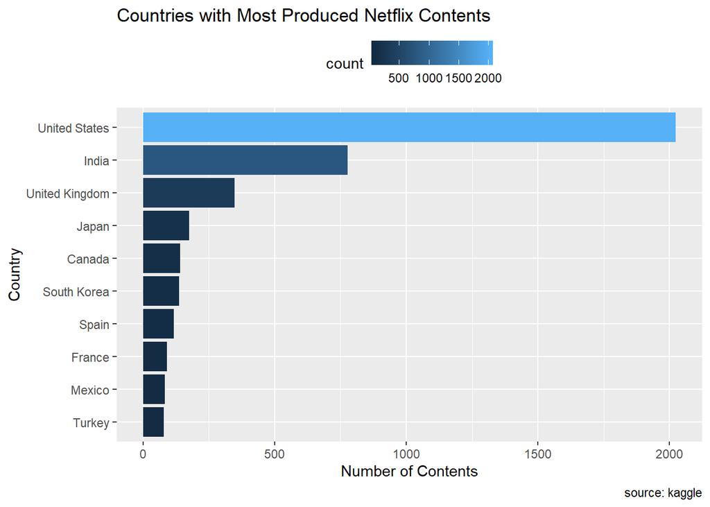

```r
ggplot(data = netflix_country, mapping = aes(x = reorder(country, count),
                                       y = count)) +
  geom_col(aes(fill = count)) +

  labs( title = "Countries with Most Produced Netflix Contents",
        y = "Number of Contents", x = "Country",
        caption = "source: kaggle") +

  coord_flip() +
  theme(legend.position = "top")
```

From above, most of the movies and TV shows are produced in the United States, India and United Kingdom.

Let’s check the number of movies produced per country and choose the top 10.

```r
netflix_country <- netflix %>%
  filter(type == "Movie") %>%
  group_by(country) %>%
  summarise(count = n()) %>%
  arrange(-count) %>%
  head(10)
```

We then visualize the data:

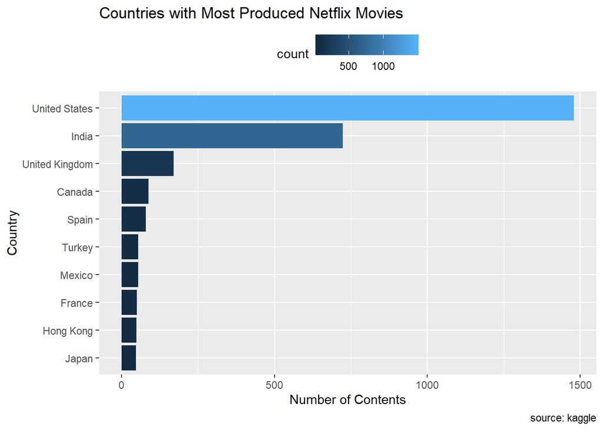

```r
ggplot(data = netflix_country, mapping = aes(x = reorder(country, count),
                                       y = count)) +
  geom_col(aes(fill = count)) +

  labs( title = "Countries with Most Produced Netflix Movies",
        y = "Number of Contents", x = "Country",
        caption = "source: kaggle") +

  coord_flip() +
  theme(legend.position = "top")
```

Most movies are produced in the U.S., India and the U.K. This is similar with the overall production of Netflix contents. However, Canada has moved to the 4th position and Spain to the 5th position.

Let’s check the number of TV shows produced per country and choose the top 10.

```r
netflix_country <- netflix %>%
  filter(type == "TV Show") %>%
  group_by(country) %>%
  summarise(count = n()) %>%
  arrange(-count) %>%
  head(10)
```

We then visualize the data:

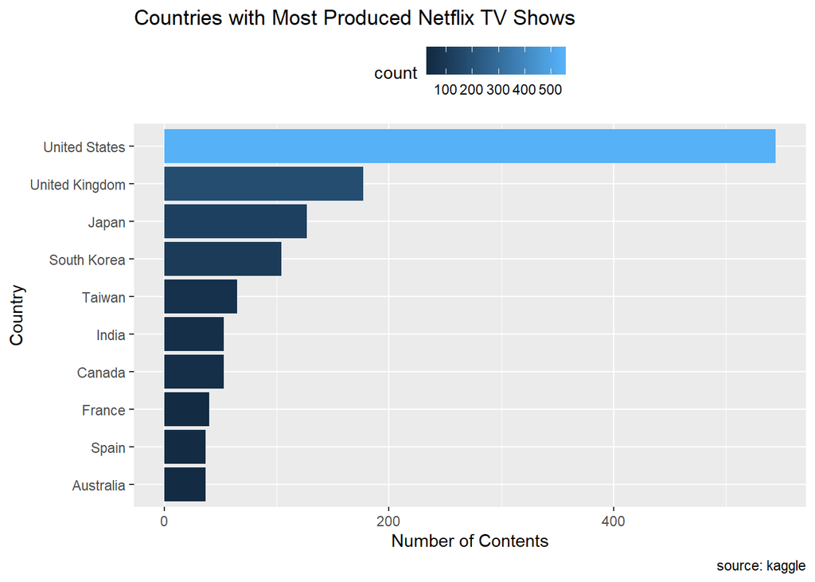

```r
ggplot(data = netflix_country, mapping = aes(x = reorder(country, count),
                                       y = count)) +
  geom_col(aes(fill = count)) +

  labs( title = "Countries with Most Produced Netflix TV Shows",
        y = "Number of Contents", x = "Country",
        caption = "source: kaggle") +

  coord_flip() +
  theme(legend.position = "top")
```

From the graph we can see that India is not on the top 3 countries in which Netflix TV shows are produced. Therefore, we can additionally conclude that India produced more movies than TV shows.

## 4.2 Question 2 (Q2)

We will now try to answer below question through visualization

Q2: What are the most produced movie or tv show’s genres on netflix?

Let’s pre-process the data and count the number of contents per genre

```r
netflix_genre <- netflix %>%
  group_by(listed_in) %>%
  summarise(count = n()) %>%
  arrange(-count) %>%
  head(10)
```

We then visualize the data:

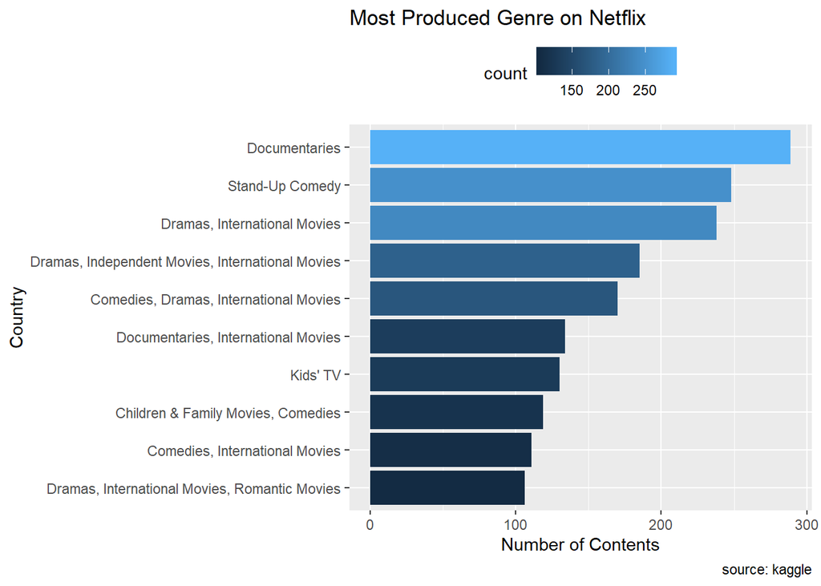

```r
ggplot(data = netflix_genre, mapping = aes(x = reorder(listed_in, count),
                                       y = count)) +
  geom_col(aes(fill = count)) +

  labs( title = "Most Produced Genre on Netflix",
        y = "Number of Contents", x = "Country",
        caption = "source: kaggle") +

  coord_flip() +
  theme(legend.position = "top")
```

The most produced genre on Netflix is Documentaries.

## 4.3 Question 3 (Q3)

We will noe analyse:

Q3: What is the trend of the content type released on Netflix?

Let’s process the data to count the number of released Movies and TV Shoes on Netflix.

First, we will process the data to be able to visualize number of released Movies over the year.

```r
netflix_trend_movie<- netflix %>%
  filter(type == "Movie")

netflix_trend_movie$date_added <- format(as.Date(netflix_trend_movie$date_added, format="%Y-%m-%d"),"%Y")

netflix_trend_movie <- netflix_trend_movie %>%
  group_by(date_added) %>%
  summarise(count = n())
```

Second, we will process the data to be able to visualize number of released TV Shows over the year.

```r
netflix_trend_tv<- netflix %>%
  filter(type == "TV Show")

netflix_trend_tv$date_added <- format(as.Date(netflix_trend_tv$date_added, format="%Y-%m-%d"),"%Y")

netflix_trend_tv <- netflix_trend_tv %>%
  group_by(date_added) %>%
  summarise(count = n())
```

Now let’s visualize both data:

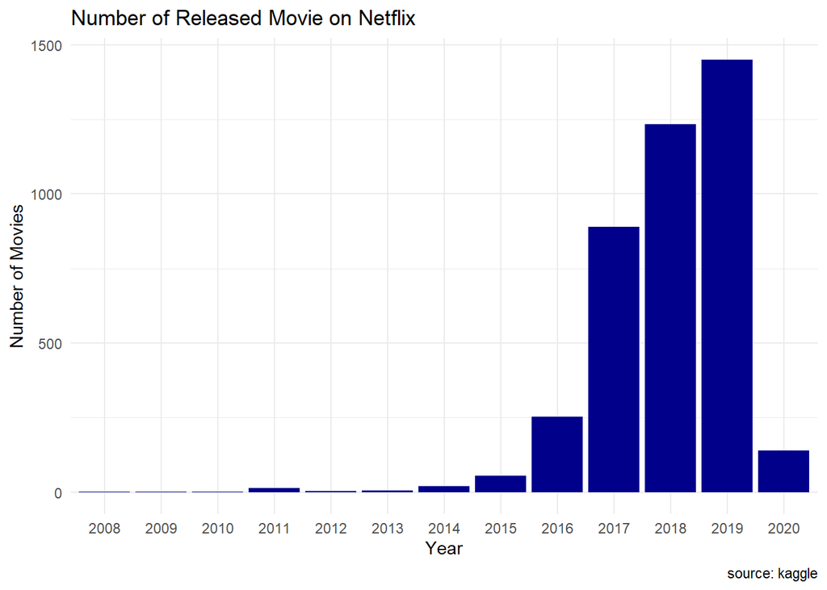

```r
# For Movies:
ggplot(data = netflix_trend_movie, mapping = aes(x = date_added,
                                       y = count)) +
  geom_col(fill = "darkblue") +

  labs( title = "Number of Released Movie on Netflix",
        y = "Number of Movies", x = "Year",
        caption = "source: kaggle") +
  theme_minimal()
```

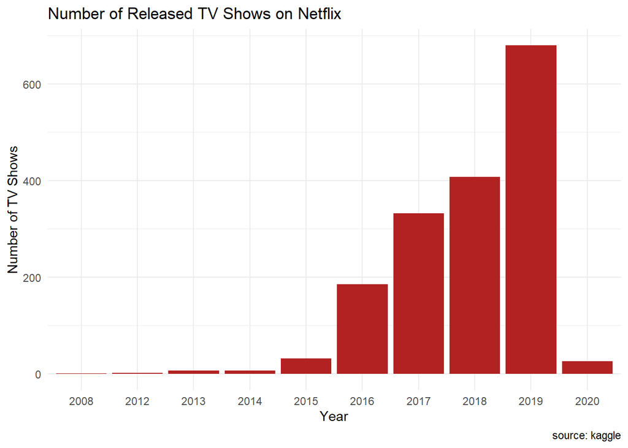

```r
# For TV Shows:
ggplot(data = netflix_trend_tv, mapping = aes(x = date_added,
                                       y = count)) +
  geom_col(fill = "firebrick") +

  labs( title = "Number of Released TV Shows on Netflix",
        y = "Number of TV Shows", x = "Year",
        caption = "source: kaggle") +
  theme_minimal()
```

From both graphs, we can see that in the number of movies released on netflix increased significatly in 2017, and now on a constant growth. On the other hand, the number of TV Shows has been growing constantly until 2019 and the number increased sharply in 2019.

# 5 Conclusion

From visualizing and answering the questions in the last chapter, we can conclude:

1. Most of netflix contents (Movies and TV Shows) are produced in the United States, India and United Kingdom.
2. Most of movies on Netflix are produced in the United States, India and United Kingdom.
3. Most of TV Shows on Netflix are produced in the United States, United Kingdom and Japan.
4. Most released contents genre on Netflix are Documentaries, Stand Up comedies and Drama.
5. The number of movies released on netflix increased significatly in 2017, and now on a constant growth.
6. The number of TV Shows has been growing constantly until 2019 and the number increased sharply in 2019.